# A COMPARISON OF ENSEMBLE LEARNING METHODS IN RETAIL SALES FORECASTING

## 2.2. Bivariate Analysis

### - Categorical & Numerical

```python
cats['is_holiday'] = cats['is_holiday'].replace({False:0, True:1})
```

```python
cats['type'] = cats['type'].replace({'A':3, 'B':2, 'C':1})
```

```python
cats = cats.astype({'date':'category'})
cats['date'] = cats['date'].cat.codes
```

```python
for i in cats.columns:
    print(i)
    print(stats.kruskal(cats[i], nums['weekly_sales']))
    print('\n')
```

```
date
KruskalResult(statistic=511861.73447293264, pvalue=0.0)


store_id
KruskalResult(statistic=567011.238749331, pvalue=0.0)


department_id
KruskalResult(statistic=538929.9249105968, pvalue=0.0)


is_holiday
KruskalResult(statistic=693882.7868950664, pvalue=0.0)


type
KruskalResult(statistic=630243.4116619534, pvalue=0.0)
```

According to Kruskal Wallis test result, sample distributions in the categorical variables are not equal.

### - Numerical & Numerical

Correlation Analysis based on "Spearman" method will be used since numerical features don't have gaussian distribution.

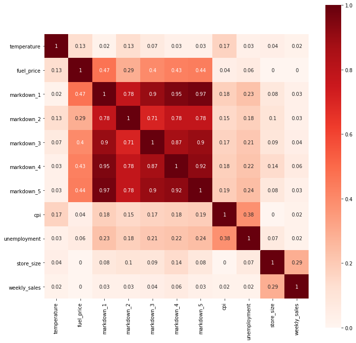

```python
plt.figure(figsize=(12, 12))
sns.heatmap(round(abs(nums.corr(method ='spearman')), 2), vmin=0, vmax=1,
            center=0.5, annot=True, cmap=plt.cm.Reds, square=True);
```

```python
round(abs(nums.corr(method ='spearman')), 2)[round(abs(nums.corr(method ='spearman')), 2) > 0.7] \
    [round(abs(nums.corr(method ='spearman')), 2) < 1.0].dropna(how='all', axis=[0, 1])
```

|  | markdown_1 | markdown_2 | markdown_3 | markdown_4 | markdown_5 |
| --- | --- | --- | --- | --- | --- |
| markdown_1 | nan | 0.78 | 0.90 | 0.95 | 0.97 |
| markdown_2 | 0.78 | nan | 0.71 | 0.78 | 0.78 |
| markdown_3 | 0.90 | 0.71 | nan | 0.87 | 0.90 |
| markdown_4 | 0.95 | 0.78 | 0.87 | nan | 0.92 |
| markdown_5 | 0.97 | 0.78 | 0.90 | 0.92 | nan |

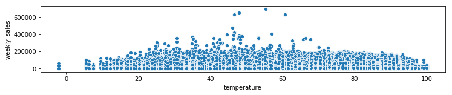

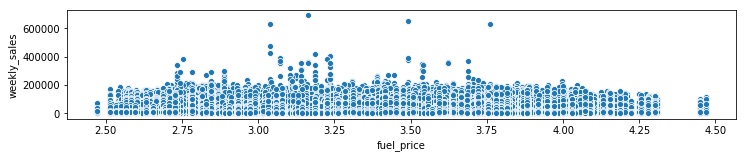

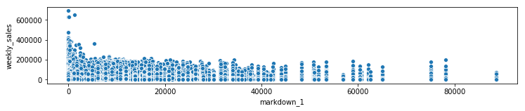

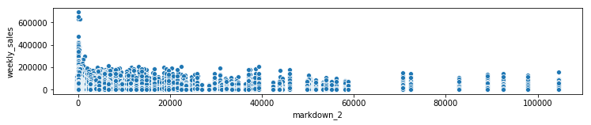

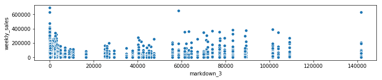

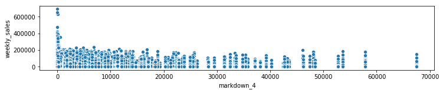

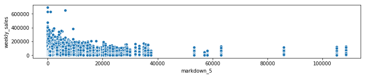

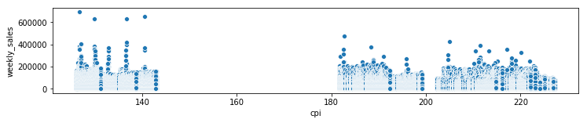

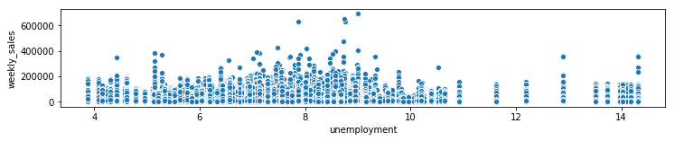

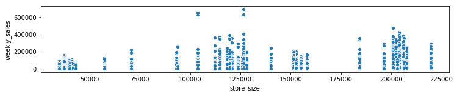

```python
for i in nums.drop('weekly_sales', axis=1).columns:
    plt.figure(figsize=(12, 2))
    sns.scatterplot(x=i, y="weekly_sales", data=nums);
```

## 2.3. Multivariate Analysis

For Multivariate Analysis, ANCOVA will be used since data has both categorical and numerical features.

```python
encoder = ce.BinaryEncoder(cols=['date', 'store_id', 'department_id', 'type'], drop_invariant=True)

cats = encoder.fit_transform(cats)
```

```python
all_columns = " + ".join(pd.concat([cats, nums], axis=1).columns)[:-15]
```

```python
formula = "weekly_sales ~ " + " + ".join(pd.concat([cats, nums], axis=1).columns)[:-15]
```

```python
results = ols(formula, data=pd.concat([cats, nums], axis=1)).fit()

results.summary()
```

OLS Regression Results

| Dep. Variable: | weekly_sales | R-squared: | 0.206 |
| --- | --- | --- | --- |
| Model: | OLS | Adj. R-squared: | 0.206 |
| Method: | Least Squares | F-statistic: | 3214. |
| Date: | Sat, 17 Aug 2019 | Prob (F-statistic): | 0.00 |
| Time: | 23:57:46 | Log-Likelihood: | -4.7782e+06 |
| No. Observations: | 421570 | AIC: | 9.556e+06 |
| Df Residuals: | 421535 | BIC: | 9.557e+06 |
| Df Model: | 34 |  |  |
| Covariance Type: | nonrobust |  |  |

|  | coef | std err | t | P>\|t\| | [0.025 | 0.975] |
| --- | --- | --- | --- | --- | --- | --- |
| Intercept | 3653.2448 | 544.888 | 6.705 | 0.000 | 2585.281 | 4721.208 |
| date_1 | -2224.1080 | 204.779 | -10.861 | 0.000 | -2625.468 | -1822.748 |
| date_2 | -838.1271 | 135.521 | -6.184 | 0.000 | -1103.745 | -572.509 |
| date_3 | 302.3754 | 80.921 | 3.737 | 0.000 | 143.772 | 460.979 |
| date_4 | -866.3067 | 72.645 | -11.925 | 0.000 | -1008.689 | -723.924 |
| date_5 | 288.3024 | 63.910 | 4.511 | 0.000 | 163.040 | 413.564 |
| date_6 | -27.5145 | 63.739 | -0.432 | 0.666 | -152.442 | 97.413 |
| date_7 | 572.1822 | 62.860 | 9.103 | 0.000 | 448.979 | 695.385 |
| date_8 | 407.0491 | 64.130 | 6.347 | 0.000 | 281.357 | 532.742 |
| store_id_1 | -3601.4939 | 97.962 | -36.764 | 0.000 | -3793.496 | -3409.492 |
| store_id_2 | -2361.4000 | 79.252 | -29.796 | 0.000 | -2516.732 | -2206.068 |
| store_id_3 | -2343.2278 | 70.656 | -33.164 | 0.000 | -2481.712 | -2204.744 |
| store_id_4 | 550.0473 | 67.001 | 8.210 | 0.000 | 418.727 | 681.368 |
| store_id_5 | 1050.8598 | 66.736 | 15.747 | 0.000 | 920.059 | 1181.660 |
| store_id_6 | -879.1133 | 69.998 | -12.559 | 0.000 | -1016.307 | -741.919 |
| department_id_1 | 1.216e+04 | 97.464 | 124.806 | 0.000 | 1.2e+04 | 1.24e+04 |
| department_id_2 | -461.8359 | 68.871 | -6.706 | 0.000 | -596.821 | -326.851 |
| department_id_3 | -9101.2918 | 68.638 | -132.598 | 0.000 | -9235.821 | -8966.762 |
| department_id_4 | -3416.1508 | 63.879 | -53.478 | 0.000 | -3541.353 | -3290.949 |
| department_id_5 | 5163.6732 | 63.079 | 81.860 | 0.000 | 5040.040 | 5287.307 |
| department_id_6 | 890.3186 | 62.562 | 14.231 | 0.000 | 767.698 | 1012.939 |
| department_id_7 | 817.6653 | 62.447 | 13.094 | 0.000 | 695.270 | 940.060 |
| is_holiday | 878.7912 | 135.363 | 6.492 | 0.000 | 613.483 | 1144.099 |
| type_1 | 5233.3740 | 186.657 | 28.037 | 0.000 | 4867.532 | 5599.216 |
| type_2 | 4514.6393 | 149.799 | 30.138 | 0.000 | 4221.037 | 4808.241 |
| temperature | 23.8851 | 2.163 | 11.042 | 0.000 | 19.645 | 28.125 |
| fuel_price | 428.7193 | 138.175 | 3.103 | 0.002 | 157.900 | 699.539 |
| markdown_1 | 0.0242 | 0.011 | 2.221 | 0.026 | 0.003 | 0.046 |
| markdown_2 | -0.0090 | 0.007 | -1.324 | 0.186 | -0.022 | 0.004 |
| markdown_3 | 0.1118 | 0.006 | 18.218 | 0.000 | 0.100 | 0.124 |
| markdown_4 | -0.0178 | 0.015 | -1.166 | 0.244 | -0.048 | 0.012 |
| markdown_5 | 0.0844 | 0.009 | 9.543 | 0.000 | 0.067 | 0.102 |
| cpi | -24.3701 | 0.964 | -25.273 | 0.000 | -26.260 | -22.480 |
| unemployment | -383.7861 | 19.899 | -19.287 | 0.000 | -422.787 | -344.785 |
| store_size | 0.1057 | 0.001 | 105.129 | 0.000 | 0.104 | 0.108 |

| Omnibus: | 302865.229 | Durbin-Watson: | 1.517 |
| --- | --- | --- | --- |
| Prob(Omnibus): | 0.000 | Jarque-Bera (JB): | 13509317.665 |
| Skew: | 2.971 | Prob(JB): | 0.00 |
| Kurtosis: | 30.088 | Cond. No. | 2.77e+06 |

Warnings:  
[1] Standard Errors assume that the covariance matrix of the errors is correctly specified.  
[2] The condition number is large, 2.77e+06. This might indicate that there are  
strong multicollinearity or other numerical problems.

# 3. Methodology

## 3.1. Data Preprocessing

Firstly, variables will be split into two sets as "features" and "target" in order to implement preprocessing easily.

```python
features = data.drop('weekly_sales', axis=1)
target = pd.DataFrame(data['weekly_sales'], columns=['weekly_sales'])
```

### - Missing Value Treatment

```python
features.isna().mean()
```

```
date            0.00
store_id        0.00
department_id   0.00
is_holiday      0.00
temperature     0.00
fuel_price      0.00
markdown_1      0.64
markdown_2      0.74
markdown_3      0.67
markdown_4      0.68
markdown_5      0.64
cpi             0.00
unemployment    0.00
type            0.00
store_size      0.00
dtype: float64
```

```python
target.isna().mean()
```

```
weekly_sales   0.00
dtype: float64
```

```python
features[['markdown_1','markdown_2','markdown_3','markdown_4', 'markdown_5']] = \
    features[['markdown_1','markdown_2','markdown_3','markdown_4', 'markdown_5']].fillna(0)
```

```python
features.isna().sum()
```

```
date             0
store_id         0
department_id    0
is_holiday       0
temperature      0
fuel_price       0
markdown_1       0
markdown_2       0
markdown_3       0
markdown_4       0
markdown_5       0
cpi              0
unemployment     0
type             0
store_size       0
dtype: int64
```

### - Outlier Treatment

Identifying the outliers in continuous variables based on IQR Score Method:

```python
def find_outliers(data, column_list):
    for i in column_list:
        Q1 = data[i].quantile(0.25)
        Q3 = data[i].quantile(0.75)
        IQR = Q3 - Q1
        print(i + ' ' * (13 - len(i)) + ': ' +
              str(len(data[i][(data[i] < (Q1 - 3 * IQR)) | (data[i] > (Q3 + 3 * IQR))])))

find_outliers(features, features.select_dtypes(include=['int64', 'float64']).columns)
```

```
store_id     : 0
department_id: 0
temperature  : 0
fuel_price   : 0
markdown_1   : 26162
markdown_2   : 98958
markdown_3   : 75196
markdown_4   : 61565
markdown_5   : 14028
cpi          : 0
unemployment : 13756
store_size   : 0
```

```python
find_outliers(features[features > 0], ['markdown_1', 'markdown_2', 'markdown_3', 'markdown_4', 'markdown_5'])
```

```
markdown_1   : 3739
markdown_2   : 12149
markdown_3   : 13652
markdown_4   : 6659
markdown_5   : 3834
```

```python
find_outliers(target, ['weekly_sales'])
```

```
weekly_sales : 12830
```

### - Feature Extraction

```python
features = features.astype({'date':'datetime64'})
features['week_number'] = features['date'].dt.week
features = features.drop('date', axis=1)
```

### - Label Encoding

```python
le = LabelEncoder()
features['is_holiday'] = le.fit_transform(features['is_holiday'])
features['type'] = le.fit_transform(features['type'])
```

### - Feature Selection

```python
print(sorted(features[features['is_holiday'] == True]['week_number'].unique()))
print(sorted(features[features['is_holiday'] == False]['week_number'].unique()))
```

```
[6, 36, 47, 52]
[1, 2, 3, 4, 5, 7, 8, 9, 10, 11, 12, 13, 14, 15, 16, 17, 18, 19, 20, 21, 22, 23, 24, 25, 26, 27, 28, 29, 30, 31, 32, 33, 34, 35, 37, 38, 39, 40, 41, 42, 43, 44, 45, 46, 48, 49, 50, 51]
```

Since "week_number" represents the information which "is_holiday" variable offers, "is_holiday" will be dropped.

```python
features = features.drop('is_holiday', axis=1)
```

**Based on Pairwise Correlation**

```python
corr_data = round(abs(pd.concat([features, target], axis=1).corr(method ='spearman')), 2)
```

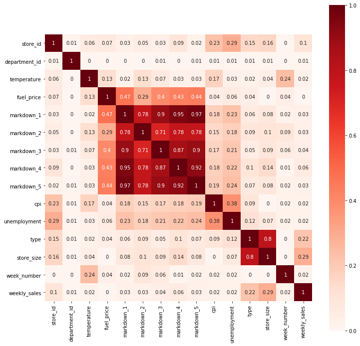

```python
plt.figure(figsize=(12, 12))
sns.heatmap(corr_data, vmin=0, vmax=1, center=0.5, annot=True, cmap=plt.cm.Reds, square=True);
```

```python
corr_data[corr_data > 0.7][corr_data < 1.0].dropna(how='all', axis=[0, 1])
```

|  | markdown_1 | markdown_2 | markdown_3 | markdown_4 | markdown_5 | type | store_size |
| --- | --- | --- | --- | --- | --- | --- | --- |
| markdown_1 | nan | 0.78 | 0.90 | 0.95 | 0.97 | nan | nan |
| markdown_2 | 0.78 | nan | 0.71 | 0.78 | 0.78 | nan | nan |
| markdown_3 | 0.90 | 0.71 | nan | 0.87 | 0.90 | nan | nan |
| markdown_4 | 0.95 | 0.78 | 0.87 | nan | 0.92 | nan | nan |
| markdown_5 | 0.97 | 0.78 | 0.90 | 0.92 | nan | nan | nan |
| type | nan | nan | nan | nan | nan | nan | 0.80 |
| store_size | nan | nan | nan | nan | nan | 0.80 | nan |

```python
pd.DataFrame({'Features':corr_data['weekly_sales'].sort_values(ascending=False).index,
              'Corr. with Target':corr_data['weekly_sales'].sort_values(ascending=False).values}).drop(0, axis=0)
```

|  | Features | Corr. with Target |
| --- | --- | --- |
| 1 | store_size | 0.29 |
| 2 | type | 0.22 |
| 3 | store_id | 0.10 |
| 4 | markdown_4 | 0.06 |
| 5 | markdown_3 | 0.04 |
| 6 | markdown_5 | 0.03 |
| 7 | markdown_2 | 0.03 |
| 8 | markdown_1 | 0.03 |
| 9 | week_number | 0.02 |
| 10 | unemployment | 0.02 |
| 11 | cpi | 0.02 |
| 12 | temperature | 0.02 |
| 13 | department_id | 0.01 |
| 14 | fuel_price | 0.00 |

Since "markdown_4" and "store_size" features have higher correlation with the target, other variables having high correlation will be dropped:

```python
features = features.drop(['markdown_3', 'markdown_2', 'markdown_5', 'markdown_1', 'type'], axis=1)
```

**Based on Variance**

```python
pd.DataFrame({'Features':features.var().index, 'Variance':features.var().values}).sort_values('Variance')
```

|  | Features | Variance |
| --- | --- | --- |
| 3 | fuel_price | 0.21 |
| 6 | unemployment | 3.47 |
| 0 | store_id | 163.46 |
| 8 | week_number | 200.28 |
| 2 | temperature | 340.33 |
| 1 | department_id | 929.77 |
| 5 | cpi | 1533.45 |
| 4 | markdown_4 | 15167363.50 |
| 7 | store_size | 3718631543.03 |

Since "fuel_price" has very low variation, it will be dropped.

```python
features = features.drop('fuel_price', axis=1)
```

**Based on Feature Importance**

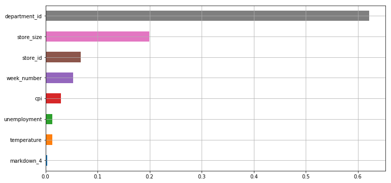

```python
model = RandomForestRegressor(random_state=1)
model.fit(features, target)
feat_importances = pd.Series(model.feature_importances_, index=features.columns)
plt.figure(figsize=(12, 6))
feat_importances.sort_values().plot(kind='barh', grid=True)
plt.show()
```

```python
pd.DataFrame({'Features':feat_importances.sort_values(ascending=False).index,
              'Importances':feat_importances.sort_values(ascending=False).values})
```

|  | Features | Importances |
| --- | --- | --- |
| 0 | department_id | 0.62 |
| 1 | store_size | 0.20 |
| 2 | store_id | 0.07 |
| 3 | week_number | 0.05 |
| 4 | cpi | 0.03 |
| 5 | unemployment | 0.01 |
| 6 | temperature | 0.01 |
| 7 | markdown_4 | 0.00 |

According to feature importance output, 'markdown_4' will be dropped since it doesn't have a significant feature importance.

```python
features = features.drop('markdown_4', axis=1)
```

### - One Hot Encoding

Since the scope of this study contains only tree-based models, one hot encoding will not be applied.

### - Feature Scaling

Since the scope of this study contains only tree-based models, feature scaling will not be applied.

### - Train-Test Split

```python
x_train_val, x_test, y_train_val, y_test = train_test_split(features, target, test_size=0.2, random_state=0)

x_train, x_val, y_train, y_val = train_test_split(x_train_val, y_train_val, test_size=0.25, random_state=0)
```

```python
print('x_train : {0:.{1}f}%'.format(x_train.shape[0] / features.shape[0] * 100, 0))
print('y_train : {0:.{1}f}%'.format(y_train.shape[0] / target.shape[0] * 100, 0))
print('\n')
print('x_val   : {0:.{1}f}%'.format(x_val.shape[0] / features.shape[0] * 100, 0))
print('y_val   : {0:.{1}f}%'.format(y_val.shape[0] / target.shape[0] * 100, 0))
print('\n')
print('x_test  : {0:.{1}f}%'.format(x_test.shape[0] / features.shape[0] * 100, 0))
print('y_test  : {0:.{1}f}%'.format(y_test.shape[0] / target.shape[0] * 100, 0))
```

```
x_train : 60%
y_train : 60%


x_val   : 20%
y_val   : 20%


x_test  : 20%
y_test  : 20%
```

## 3.2. Model Building

**A. Bootstrap Aggregation**  
--- Bagging (BaggingRegressor)  
--- Random Forest (RandomForestRegressor)  
--- Extremely Randomized Trees (ExtraTreesRegressor)

**B. Boosting**  
--- Adaptive Boosting (AdaBoostRegressor)  
--- Extreme Gradient Boosting (XGBoost)

**C. Stacked Generalization**  
--- Voting Regressor (VotingRegressor)

In order to obtain reasonable comparison, the maximum depths of the model was selected same in all models as 7 for the beginning.  
Different values of depth will be tried in the stage of hyperparameter tuning.

```python
models = {'Bagging' : BaggingRegressor(base_estimator=DecisionTreeRegressor(max_depth=7, random_state=1),
                                       n_estimators=100,
                                       n_jobs=-1,
                                       random_state=1),
          'Random F.' : RandomForestRegressor(n_estimators=100,
                                              max_depth=7,
                                              n_jobs=-1,
                                              random_state=1),
          'Extra T.' : ExtraTreesRegressor(n_estimators=100,
                                           max_depth=7,
                                           n_jobs=-1,
                                           random_state=1),
          'AdaBoost' : AdaBoostRegressor(base_estimator=DecisionTreeRegressor(max_depth=7, random_state=1),
                                         n_estimators=100,
                                         learning_rate=0.1,
                                         random_state=1),
          'XGBoost' : xgb.XGBRegressor(n_estimators=100,
                                       learning_rate=0.1,
                                       max_depth=7,
                                       n_jobs=-1,
                                       random_state=1)}
```

```python
model_name = list(models.keys())
mae_scores = []
rmse_scores = []
r2_scores = []
times = []

for i in models:
    start = time.time()
    model = models[i]
    model.fit(x_train, y_train)
    y_pred = model.predict(x_val)
    mae_scores.append(mean_absolute_error(y_val, y_pred))
    rmse_scores.append(sqrt(mean_squared_error(y_val, y_pred)))
    r2_scores.append(r2_score(y_val, y_pred))
    end = time.time()
    times.append(end - start)

compare_list =  list(zip(model_name, mae_scores, rmse_scores, r2_scores, times))
compare = pd.DataFrame(compare_list, columns = ['Model', 'MAE' , 'RMSE', 'R2', 'Time(sec)'])
compare
```

|  | Model | MAE | RMSE | R2 | Time(sec) |
| --- | --- | --- | --- | --- | --- |
| 0 | Bagging | 6416.67 | 10744.16 | 0.78 | 21.77 |
| 1 | Random F. | 6416.66 | 10744.16 | 0.78 | 16.20 |
| 2 | Extra T. | 9494.05 | 15431.75 | 0.54 | 6.82 |
| 3 | AdaBoost | 7409.14 | 10562.46 | 0.78 | 67.83 |
| 4 | XGBoost | 3232.75 | 5740.16 | 0.94 | 10.88 |

In stacked generalization algorithm, XGBoost, AdaBoost and Random Forest will be used since they have higher scores than other models.

```python
model = VotingRegressor(estimators=[('xg', xgb.XGBRegressor(n_estimators=100,
                                                             learning_rate=0.1,
                                                             max_depth=7,
                                                             n_jobs=-1,
                                                             random_state=1)),
                                    ('ad', AdaBoostRegressor(base_estimator=DecisionTreeRegressor(max_depth=7,
                                                                                                  random_state=1),
                                                             n_estimators=100,
                                                             learning_rate=0.1,
                                                             random_state=1)),
                                    ('rf', RandomForestRegressor(n_estimators=100,
                                                                 max_depth=7,
                                                                 n_jobs=-1,
                                                                 random_state=1))],
                        n_jobs=-1)

model_name.append('VotingReg')
models['VotingReg'] = model
start = time.time()
model.fit(x_train, y_train)
y_pred = model.predict(x_val)
mae_scores.append(mean_absolute_error(y_val, y_pred))
rmse_scores.append(sqrt(mean_squared_error(y_val, y_pred)))
r2_scores.append(r2_score(y_val, y_pred))
end = time.time()
times.append(end - start)

compare_list =  list(zip(model_name, mae_scores, rmse_scores, r2_scores, times))
compare = pd.DataFrame(compare_list, columns = ['Model', 'MAE' , 'RMSE', 'R2', 'Time(sec)'])
compare
```

|  | Model | MAE | RMSE | R2 | Time(sec) |
| --- | --- | --- | --- | --- | --- |
| 0 | Bagging | 6416.67 | 10744.16 | 0.78 | 21.77 |
| 1 | Random F. | 6416.66 | 10744.16 | 0.78 | 16.20 |
| 2 | Extra T. | 9494.05 | 15431.75 | 0.54 | 6.82 |
| 3 | AdaBoost | 7409.14 | 10562.46 | 0.78 | 67.83 |
| 4 | XGBoost | 3232.75 | 5740.16 | 0.94 | 10.88 |
| 5 | VotingReg | 5300.15 | 8330.09 | 0.87 | 90.27 |

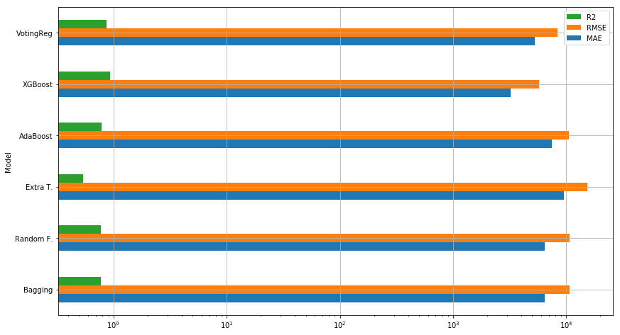

```python
compare.plot(kind='barh',
             x='Model',
             y=['MAE' , 'RMSE', 'R2'],
             figsize=(14, 8),
             logx=True,
             grid=True,
             legend='reverse');
```

## 3.3. Model Evaluation

### 3.3.1. Performance Metrics

```python
def take_second(x):
    return x[1]
```

**Mean Absolute Error**

```python
for i, j in sorted(zip(model_name, mae_scores), key=take_second, reverse=False):
    print(i + ' ' * (12 - len(i)) + ': {0:.{1}f}'.format(j, 2))
```

```
XGBoost     : 3232.75
VotingReg   : 5300.15
Random F.   : 6416.66
Bagging     : 6416.67
AdaBoost    : 7409.14
Extra T.    : 9494.05
```

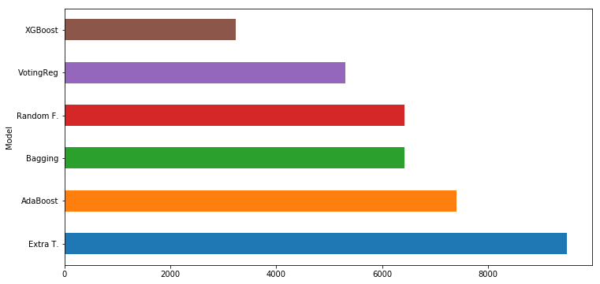

```python
compare.sort_values('MAE', ascending=False).plot(kind='barh',
                                                 x='Model',
                                                 y='MAE',
                                                 figsize=(12, 6),
                                                 legend=False);
```

**Root Mean Squared Error**

```python
for i, j in sorted(zip(model_name, rmse_scores), key=take_second, reverse=False):
    print(i + ' ' * (12 - len(i)) + ': {0:.{1}f}'.format(j, 2))
```

```
XGBoost     : 5740.16
VotingReg   : 8330.09
AdaBoost    : 10562.46
Bagging     : 10744.16
Random F.   : 10744.16
Extra T.    : 15431.75
```

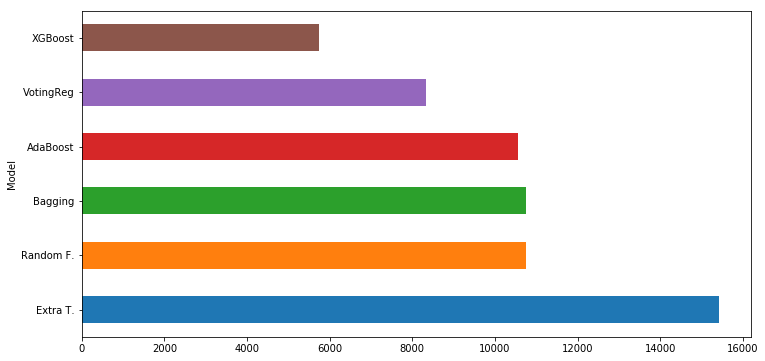

```python
compare.sort_values('RMSE', ascending=False).plot(kind='barh',
                                                  x='Model',
                                                  y='RMSE',
                                                  figsize=(12, 6),
                                                  legend=False);
```

**R-Square**

```python
for i, j in sorted(zip(model_name, r2_scores), key=take_second, reverse=True):
    print(i + ' ' * (12 - len(i)) + ': {0:.{1}f}'.format(j, 2))
```

```
XGBoost     : 0.94
VotingReg   : 0.87
AdaBoost    : 0.78
Bagging     : 0.78
Random F.   : 0.78
Extra T.    : 0.54
```

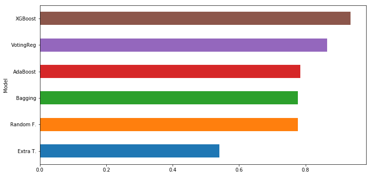

```python
compare.sort_values('R2').plot(kind='barh',
                               x='Model',
                               y='R2',
                               figsize=(12, 6),
                               legend=False);
```

**Runtime**

```python
for i, j in sorted(zip(model_name, times), key=take_second, reverse=False):
    print(i + ' ' * (12 - len(i)) + ': {0:.{1}f}'.format(j, 2))
```

```
Extra T.    : 6.82
XGBoost     : 10.88
Random F.   : 16.20
Bagging     : 21.77
AdaBoost    : 67.83
VotingReg   : 90.27
```

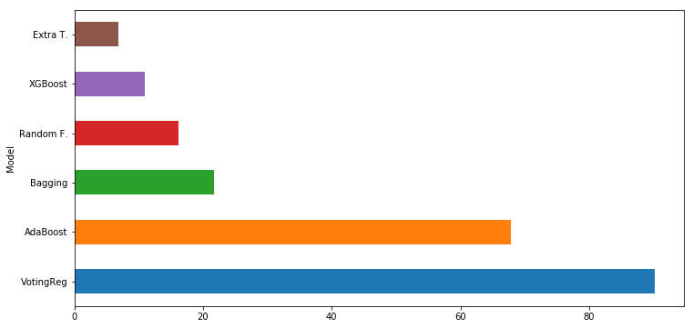

```python
compare.sort_values('Time(sec)', ascending=False).plot(kind='barh',
                                                       x='Model',
                                                       y='Time(sec)',
                                                       figsize=(12, 6),
                                                       legend=False);
```

### 3.3.2. Cross-Validation

In order to achieve an unbiased estimate of the model performance, 5-fold cross-validation will be used.

```python
all_mae_scores = []
all_rmse_scores = []
all_r2_scores = []
all_times = []

for i in models:
    mae_scores = []
    rmse_scores = []
    r2_scores = []
    times = []
    model = models[i]
    cv = KFold(n_splits=5)
    for train_index, test_index in cv.split(x_train_val.values):
        start = time.time()
        x_train, x_val, y_train, y_val = x_train_val.iloc[train_index], x_train_val.iloc[test_index], \
                                            y_train_val.iloc[train_index], y_train_val.iloc[test_index]
        model.fit(x_train, y_train)
        y_pred = model.predict(x_val)
        mae_scores.append(mean_absolute_error(y_val, y_pred))
        rmse_scores.append(sqrt(mean_squared_error(y_val, y_pred)))
        r2_scores.append(r2_score(y_val, y_pred))
        end = time.time()
        times.append(end - start)
    all_mae_scores.append(sum(mae_scores) / len(mae_scores))
    all_rmse_scores.append(sum(rmse_scores) / len(rmse_scores))
    all_r2_scores.append(sum(r2_scores) / len(r2_scores))
    all_times.append(round(sum(times) / len(times)))

compare_list_cv =  list(zip(model_name, all_mae_scores, all_rmse_scores, all_r2_scores, all_times))
compare_cv = pd.DataFrame(compare_list_cv, columns = ['Model', 'MAE' , 'RMSE', 'R2', 'Time(sec)'])
compare_cv.sort_values('MAE')
```

|  | Model | MAE | RMSE | R2 | Time(sec) |
| --- | --- | --- | --- | --- | --- |
| 4 | XGBoost | 3238.91 | 5792.23 | 0.93 | 11 |
| 5 | VotingReg | 5269.71 | 8309.80 | 0.87 | 94 |
| 1 | Random F. | 6434.12 | 10808.14 | 0.77 | 15 |
| 0 | Bagging | 6434.12 | 10808.14 | 0.77 | 19 |
| 3 | AdaBoost | 7230.23 | 10350.51 | 0.79 | 70 |
| 2 | Extra T. | 9510.82 | 15397.08 | 0.54 | 8 |

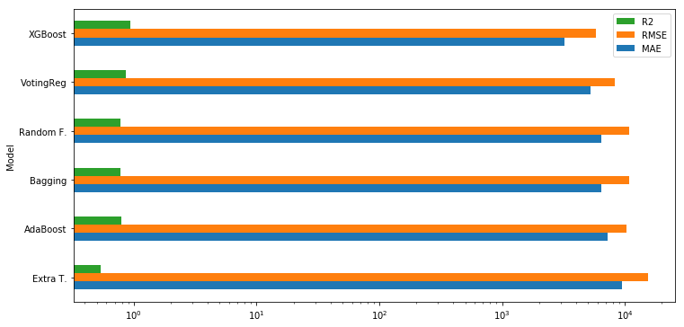

```python
compare_cv.sort_values('MAE', ascending=False).plot(kind='barh',
                                                    x='Model',
                                                    y=['MAE' , 'RMSE', 'R2'],
                                                    logx=True,
                                                    legend='reverse',
                                                    figsize=(12, 6));
```

### 3.3.3. Hyperparameter Optimization

```python
grid_param = {'n_estimators'     : range(100, 1000, 100),
              'learning_rate'    : [0.01, 0.05, 0.1],
              'max_depth'        : range(3, 11),
              'gamma'            : [0, 1, 5],
              'subsample'        : [0.8, 0.9, 1.0],
              'colsample_bytree' : [0.8, 0.9, 1.0]}

xgb_grid = xgb.XGBRegressor(n_jobs=-1,
                            random_state=1)

cv = KFold(n_splits=5)

grid = RandomizedSearchCV(estimator=xgb_grid,
                          param_distributions=grid_param,
                          scoring='neg_mean_absolute_error',
                          cv=cv,
                          n_iter=5,
                          n_jobs=-1,
                          random_state=1)

grid.fit(x_train, y_train)

print(grid.best_params_, -grid.best_score_)
```

```
{'subsample': 0.8, 'n_estimators': 100, 'max_depth': 10, 'learning_rate': 0.1, 'gamma': 1, 'colsample_bytree': 1.0} 1974.4839897895286
```

```python
y_pred = grid.best_estimator_.predict(x_val)
print('Mean Absolute Error for Validation: {0:.{1}f}'.format(mean_absolute_error(y_val, y_pred), 2))
```

```
Mean Absolute Error for Validation: 1983.72
```

```python
y_pred_test = grid.best_estimator_.predict(x_test)
print('Mean Absolute Error for Test: {0:.{1}f}'.format(mean_absolute_error(y_test, y_pred_test), 2))
```

```
Mean Absolute Error for Test: 1957.25
```

```python
model = xgb.XGBRegressor(learning_rate=0.05,
                         n_estimators=200,
                         max_depth=10,
                         gamma=1,
                         subsample=0.8,
                         colsample_bytree=1,
                         n_jobs=-1,
                         random_state=1)
model.fit(x_train, y_train)
y_pred_test = model.predict(x_test)
print('Final Mean Absolute Error: {0:.{1}f}'.format(mean_absolute_error(y_test, y_pred_test), 2))
```

```
Final Mean Absolute Error: 1951.52
```